# Bioinformatics - R Dataframe and Plots

Wei-Hao, Lee

3/28/2019

## Outline

### 0. Review

#### 註解 (Comment)

註解就是替程式增添文字上的說明，方便日後重新閱讀程式能夠快速了解當初的原意。在R語言中只提供單行註解，利用`# 你想打的東西放在井字號後都是註解喔～`，舉例來說：

```r
num <- "Wei-Hao" # 這是名字
# 也可以獨立出一行作註解
```

同時也可以利用註解的功能，將部分的程式改為註解，就不會執行了！

```r
age <- 18
# age <- age + 2
print(age)
```

```
## [1] 18
```

#### 縮排 (Indent)

縮排其實就是利用tab鍵使文字內縮，就像寫作文分段時會留空告訴讀者這是新的一段。在程式語言中，縮排可以幫助理解程式的邏輯以及架構，舉例來說：

```r
age <- 30
if (age > 18) {
    print("Older than 18!") # 這裡就是按了一個tab鍵做程式的縮排
}
```

```
## [1] "Older than 18!"
```

如果程式不使用縮排時會導致程式難以閱讀，看以下九九乘法表範例：

```r
for (i in 1:9)
{
for (j in 1:9)
{
cat(i, "*", j, "=", i*j, "\t")
}
cat("\n")
}
```

是不是變得難以理解了呢，如果我們的使用縮排就可以明顯看出層級關係了喔！

```r
for (i in 1:9)
{
    for (j in 1:9)
    {
        cat(i, "*", j, "=", i*j, "\t")
    }
    cat("\n")
}
```

#### 作業講解 – 九九乘法表 (僅供參考)

**程式並沒有一定的答案，只要寫得出來就是對的答案，這堂課只需要練習出寫出對的答案，無需追求執行速度**

```r
# 現練習用for迴圈印出1~9並且分行印出
for (i in 1:9)
{
    cat(i)
    cat("\n") # \n 換行符號代表 newline
}
```

```
## 1
## 2
## 3
## 4
## 5
## 6
## 7
## 8
## 9
```

```r
for (i in 1:9)
{
    # 其實很簡單，我們在這邊在加入一個for迴圈，負責印出1~9
    for (j in 1:9) # 切記這裡變數不可以在使用i
    {
        cat("i:j=", i, ":", j, "\t", sep="")
    }
    cat("\n")
}
```

```
## i:j=1:1  i:j=1:2 i:j=1:3 i:j=1:4 i:j=1:5 i:j=1:6 i:j=1:7 i:j=1:8 i:j=1:9
## i:j=2:1  i:j=2:2 i:j=2:3 i:j=2:4 i:j=2:5 i:j=2:6 i:j=2:7 i:j=2:8 i:j=2:9
## i:j=3:1  i:j=3:2 i:j=3:3 i:j=3:4 i:j=3:5 i:j=3:6 i:j=3:7 i:j=3:8 i:j=3:9
## i:j=4:1  i:j=4:2 i:j=4:3 i:j=4:4 i:j=4:5 i:j=4:6 i:j=4:7 i:j=4:8 i:j=4:9
## i:j=5:1  i:j=5:2 i:j=5:3 i:j=5:4 i:j=5:5 i:j=5:6 i:j=5:7 i:j=5:8 i:j=5:9
## i:j=6:1  i:j=6:2 i:j=6:3 i:j=6:4 i:j=6:5 i:j=6:6 i:j=6:7 i:j=6:8 i:j=6:9
## i:j=7:1  i:j=7:2 i:j=7:3 i:j=7:4 i:j=7:5 i:j=7:6 i:j=7:7 i:j=7:8 i:j=7:9
## i:j=8:1  i:j=8:2 i:j=8:3 i:j=8:4 i:j=8:5 i:j=8:6 i:j=8:7 i:j=8:8 i:j=8:9
## i:j=9:1  i:j=9:2 i:j=9:3 i:j=9:4 i:j=9:5 i:j=9:6 i:j=9:7 i:j=9:8 i:j=9:9
```

有沒有發現，其實這已經就是九九乘法了嗎？我們再稍微修改一下印出的格式即可囉～

```r
for (i in 1:9)
{
    for (j in 1:9)
    {
        cat(i, "*", j, "=", i*j, "\t") # 其實要印出兩數字相乘，直接在cat函式中數入i*j就可以了喔！
    }
    cat("\n")
}
```

```
## 1 * 1 = 1    1 * 2 = 2   1 * 3 = 3   1 * 4 = 4   1 * 5 = 5   1 * 6 = 6   1 * 7 = 7   1 * 8 = 8   1 * 9 = 9
## 2 * 1 = 2    2 * 2 = 4   2 * 3 = 6   2 * 4 = 8   2 * 5 = 10  2 * 6 = 12  2 * 7 = 14  2 * 8 = 16  2 * 9 = 18
## 3 * 1 = 3    3 * 2 = 6   3 * 3 = 9   3 * 4 = 12  3 * 5 = 15  3 * 6 = 18  3 * 7 = 21  3 * 8 = 24  3 * 9 = 27
## 4 * 1 = 4    4 * 2 = 8   4 * 3 = 12  4 * 4 = 16  4 * 5 = 20  4 * 6 = 24  4 * 7 = 28  4 * 8 = 32  4 * 9 = 36
## 5 * 1 = 5    5 * 2 = 10  5 * 3 = 15  5 * 4 = 20  5 * 5 = 25  5 * 6 = 30  5 * 7 = 35  5 * 8 = 40  5 * 9 = 45
## 6 * 1 = 6    6 * 2 = 12  6 * 3 = 18  6 * 4 = 24  6 * 5 = 30  6 * 6 = 36  6 * 7 = 42  6 * 8 = 48  6 * 9 = 54
## 7 * 1 = 7    7 * 2 = 14  7 * 3 = 21  7 * 4 = 28  7 * 5 = 35  7 * 6 = 42  7 * 7 = 49  7 * 8 = 56  7 * 9 = 63
## 8 * 1 = 8    8 * 2 = 16  8 * 3 = 24  8 * 4 = 32  8 * 5 = 40  8 * 6 = 48  8 * 7 = 56  8 * 8 = 64  8 * 9 = 72
## 9 * 1 = 9    9 * 2 = 18  9 * 3 = 27  9 * 4 = 36  9 * 5 = 45  9 * 6 = 54  9 * 7 = 63  9 * 8 = 72  9 * 9 = 81
```

*稍微再思考一下，如何印出直行的九九乘法表呢！*

```
## 1 * 1 = 1    2 * 1 = 2   3 * 1 = 3   4 * 1 = 4   5 * 1 = 5   6 * 1 = 6   7 * 1 = 7   8 * 1 = 8   9 * 1 = 9
## 1 * 2 = 2    2 * 2 = 4   3 * 2 = 6   4 * 2 = 8   5 * 2 = 10  6 * 2 = 12  7 * 2 = 14  8 * 2 = 16  9 * 2 = 18
## 1 * 3 = 3    2 * 3 = 6   3 * 3 = 9   4 * 3 = 12  5 * 3 = 15  6 * 3 = 18  7 * 3 = 21  8 * 3 = 24  9 * 3 = 27
## 1 * 4 = 4    2 * 4 = 8   3 * 4 = 12  4 * 4 = 16  5 * 4 = 20  6 * 4 = 24  7 * 4 = 28  8 * 4 = 32  9 * 4 = 36
## 1 * 5 = 5    2 * 5 = 10  3 * 5 = 15  4 * 5 = 20  5 * 5 = 25  6 * 5 = 30  7 * 5 = 35  8 * 5 = 40  9 * 5 = 45
## 1 * 6 = 6    2 * 6 = 12  3 * 6 = 18  4 * 6 = 24  5 * 6 = 30  6 * 6 = 36  7 * 6 = 42  8 * 6 = 48  9 * 6 = 54
## 1 * 7 = 7    2 * 7 = 14  3 * 7 = 21  4 * 7 = 28  5 * 7 = 35  6 * 7 = 42  7 * 7 = 49  8 * 7 = 56  9 * 7 = 63
## 1 * 8 = 8    2 * 8 = 16  3 * 8 = 24  4 * 8 = 32  5 * 8 = 40  6 * 8 = 48  7 * 8 = 56  8 * 8 = 64  9 * 8 = 72
## 1 * 9 = 9    2 * 9 = 18  3 * 9 = 27  4 * 9 = 36  5 * 9 = 45  6 * 9 = 54  7 * 9 = 63  8 * 9 = 72  9 * 9 = 81
```

### 1. 函式 (function)

function其實就是使用者自己定義的功能，且可以重複的使用。當一個程式大量撰寫重複的程式時，我們便可以撰寫成函式，方便使用。而我們其實已經看過很多函式像是`as.integer()`, `mean()`等。接下來就來介紹函式撰寫的方式：

```r
# 這就是最簡的 function，沒有任何功能的函式
# 函式名稱 <- function() {}
simplest_function <- function() {

}

simplest_function() # 呼叫函式時，記得一定要寫括弧
```

```r
simplest_function
```

```
## function() {
##
## }
```

我們開始在`{}`中，加入我們要使用的功能

```r
# 記得函式也要遵守變數的命名原則
hello_world <- function() {
    print("Hello World!")
}

hello_world()
```

```
## [1] "Hello World!"
```

假設今天我們要撰寫我們自己的function專門計算平均值，代表我們的function要有能力接受我們傳入的數值在去做平均值的計算。方法其實很簡單：

```r
# 在function 的“()”中設定我們要接受的資料
class_height <- 175

# 這邊的numbers其實也是個變數，專門接收我們傳入的資料，我們通常稱這些變數為parameter參數
bio_means <- function(numbers) {
    print(numbers)
}

bio_means(class_height)
```

```
## [1] 175
```

```r
# 這邊要注意！我們可以看到numbers無法被印出來
# 原因是，當function結束時，numbers這個變數也會跟著消失
print(numbers)
```

```
## Error in print(numbers): object 'numbers' not found
```

我們也可以同時傳入多個資料：

```r
name <- "Wei-Hao"
id <- 123456789

identification <- function(name, id) {
    cat("name :", name)
    cat("\n")
    cat("id :", id)
}
identification(name, id)
```

```
## name : Wei-Hao
## id : 123456789
```

```r
# 如果你明確知道哪些參數資料需要什麼樣類型的資料
# 也可以直接在function中，明確指出哪些參數等於哪些資料
identification(name="Lee", id="0217047")
```

```
## name : Lee
## id : 0217047
```

```r
weird_identification <- function(name, id) {
    name <- "BA BA BA" # change both id and name
    id <- "LA LA LA"
    cat("name :", name)
    cat("\n")
    cat("id :", id)
}
weird_identification(name, id)
```

```
## name : BA BA BA
## id : LA LA LA
```

```r
# 我們在identification更改的東西，並未直接的
cat("name :", name, "\n", "id :", id)
```

```
## name : Wei-Hao
##  id : 123456789
```

```r
# 跟identification 只差了function
tricky_identification <- function() {
    cat("name :", name)
    cat("\n")
    cat("id :", id)
}
tricky_identification()
```

```
## name : Wei-Hao
## id : 123456789
```

從上述兩個function中講了一些蠻重要的觀念：

1. function中的參數，雖然名稱與傳入的變數相同，但是是不同的東西(看`weird_identification()`的例子)，function中的參數是另外獨立屬於這個function的變數，而傳入的資料則會複製一份給參數。
2. 在看`tricky_identification()`，我們可以觀察到，若function沒有參數時，但裡面有用到已經存在的變數，他便會自動的調取這些變數做使用！

我們剛剛的例子，都只是印出東西，如果我們想要有個函式計算平均值，並且把計算完後的平均值傳給某個變數該怎麼做呢，我們只需要使用`return()`就可以達成囉！

```r
class_heights <- c(123, 145, 135 , 175, 189)

mean_height <- function(class_heights) {
    total_height <- 0
    num_of_classmate <- length(class_heights)

    for (height in class_heights)
    {
        total_height <- total_height + height
    }
    return(total_height/num_of_classmate)
}

class_mean_height <- mean_height(class_heights)

print(class_mean_height)
```

```
## [1] 153.4
```

上述都是function中蠻重要的觀念，還有一小部分沒有講到(Scope)，如果有興趣的同學可以點取連結，寫出更有彈性的function。 [Creating Functions](https://swcarpentry.github.io/r-novice-inflammation/02-func-R/index.html)

#### Practice.1 - Selection sort

Selection sort 是一種排序的方法，它的原理很簡單，請參考 [Selection Sort](https://en.wikipedia.org/wiki/Selection_sort)  
你們要寫出一個function叫`selection_sort(series)`，series是一連串的數字用vector存放，這個function要能夠回傳由小排到大的vector。請大家練習自己用for迴圈寫出來，不要使用`sort()`!! 題目有點困難，請同學思考一下，也可以參考網路上的解答，不要鑽研 big O的問題。

```r
series <- c(0, 3, 1, 13, 84, 25, 91, 1, 2)
```

```r
selection_sort(series)
```

```
## [1]  0  1  1  2  3 13 25 84 91
```

### 2. Package installation

Package其實就是別人將他寫好的function整理成一個package，提供給別人使用。通常每個package都會有他主要處理的目的，像是`dplyr`就是專門為了處理資料所使用的package，`ggplot2`專門為了繪圖所使用的package，接下來我們會教大家如何安裝package。 我們只要在console中打入`install.packages("dplyr")`，就可以開始下載`dplyr`囉！

下載完後，並非可以直接使用，你只是將package下載到電腦中。要使用時要：

```r
library(dplyr) # 可能會覺得有點怪，一下叫package一下叫library，這邊就請同學熟悉一下囉！
```

那麼這邊就麻煩同學下載今天要使用的package: `dplyr`, `ggplot2`, `ggtheme`, `reshape2`, `magrittr`

### 3. Dataframe

#### Check Data Format

dataframe是一種資料型態，最為大家熟知的就像是excel檔。然而我們在excel中可以任意使用裡面的格子，而且不需要有整齊的格式，但是在R語言甚至是python裡的pandas都是無法處理這種格式不一致的檔案。因此我們在讀取資料前，要先確人我們的資料格式正確且整齊，避免電腦無法匯入想要的資料。待會再進行資料處理時，你們也可以同時知道為什麼R語言並不支援讀取格式混亂的檔案。

首先這邊會推薦大家使用幾個好用的text editor。原先text editor其實就是提供使用編輯文字用的程式，但由於近幾年的開發，目前大多數的text editor都有編譯執行程式的功能。

- Visual Studio Code (Personal Recommendation)
- Atom
- Notepad ++
- … more

接下來要介紹幾種常見的格式`.tsv`, `csv`

```
# tsv file, 以tab鍵作為資料的分隔
1   2   3   4   5   6

# csv file, 以comma作為資料的分隔
1,2,3,4,5,6
```

#### Load Data

讀取檔案有兩種方式，一種是透過R studio做匯入，另外一種透過絕對路徑(absolute path)再搭配`read.csv()` or `read.table()`，那麼接下來主要是示範如何透過絕對路徑讀取檔案。首先絕對路徑就是一段字串告訴電腦檔案的位置 ex: `~/Documents/TeacherAssistant/Bioninformatics/2019_03_28/Iris.csv` (for Mac OSX, Linux，在mac中絕對路徑不好取得，這邊教大家使用一下偷吃步！如果會command line的同學請盡量使用command line), `C:\Documents\Newsletters\Summer2018.pdf` (for Windows，Windows的絕對路徑較好取得)。接下來就是讀取檔案

```r
# 讀取工作路徑
getwd()
```

```
## [1] "/Users/lee-weihao/Documents/TeacherAssistant/Bioninformatics/2019_03_28"
```

```r
# 設定工作路徑
# setwd()
```

```r
# how to read csv file
iris <- read.csv(file = "./Iris.csv", # file path
                 stringsAsFactors = FALSE, # 只要有文字的那行，會直接轉為factor，因使我們要取消此功能
                 row.names = 1, # 告訴電腦第一列資料是 row name
                 header = TRUE, # 第一行是 column 的名稱
                 check.names = FALSE) # check.name是幫使用者檢查 column and row name，有時候名稱會跑掉
head(iris, n=5) # 顯示 iris dataframe 前五行
```

```
##   Sepal.Length Sepal.Width Petal.Length Petal.Width Species
## 1          5.1         3.5          1.4         0.2  setosa
## 2          4.9         3.0          1.4         0.2  setosa
## 3          4.7         3.2          1.3         0.2  setosa
## 4          4.6         3.1          1.5         0.2  setosa
## 5          5.0         3.6          1.4         0.2  setosa
```

```r
# how to read tsv file
iris <- read.table(file = "./Iris.tsv", # file path
                   stringsAsFactors = FALSE, # 只要有文字的那行，會直接轉為factor，因使我們要取消此功能
                   row.names = 1, # 告訴電腦第一列資料是 row name
                   header = TRUE,
                   sep = "\t", # 設定文件是使用什麼符號做為分隔
                   check.names = FALSE) # check.name是幫使用者檢查 column and row name，有時候名稱會跑掉
head(iris, n=5) # 顯示 iris dataframe 前五行
```

```
##   Sepal.Length Sepal.Width Petal.Length Petal.Width Species
## 1          5.1         3.5          1.4         0.2  setosa
## 2          4.9         3.0          1.4         0.2  setosa
## 3          4.7         3.2          1.3         0.2  setosa
## 4          4.6         3.1          1.5         0.2  setosa
## 5          5.0         3.6          1.4         0.2  setosa
```

```r
# how to rad excel format
library(readxl)
iris_excel <- read_excel(path = "./Iris.xlsm", # file path
                   sheet = 1, # number of sheet, or you can use the name of sheet you want
                   col_names = TRUE,
                   col_types = NULL,
                   na = "", # missing value
                   skip = 0) #Number of rows to skip before reading any data.
head(iris_excel, n=5)
```

```
## # A tibble: 5 x 6
##     ..1 Sepal.Length Sepal.Width Petal.Length Petal.Width Species
##   <dbl>        <dbl>       <dbl>        <dbl>       <dbl> <chr>
## 1     1          5.1         3.5          1.4         0.2 setosa
## 2     2          4.9         3            1.4         0.2 setosa
## 3     3          4.7         3.2          1.3         0.2 setosa
## 4     4          4.6         3.1          1.5         0.2 setosa
## 5     5          5           3.6          1.4         0.2 setosa
```

*補充說明，如果是讀取excel檔的話，read_excel()會將資料整理成tibble的格式，看起來會與前面兩者有些不同，但是基本操作上是一模一樣的，但是有些功能會有異，如果想要讓他成為一般的dataframe，請使用as.data.frame()。*

```r
class(iris_excel)
```

```
## [1] "tbl_df"     "tbl"        "data.frame"
```

```r
iris_excel <- as.data.frame(iris_excel)
class(iris_excel)
```

```
## [1] "data.frame"
```

```r
head(iris_excel)
```

```
##   ..1 Sepal.Length Sepal.Width Petal.Length Petal.Width Species
## 1   1          5.1         3.5          1.4         0.2  setosa
## 2   2          4.9         3.0          1.4         0.2  setosa
## 3   3          4.7         3.2          1.3         0.2  setosa
## 4   4          4.6         3.1          1.5         0.2  setosa
## 5   5          5.0         3.6          1.4         0.2  setosa
## 6   6          5.4         3.9          1.7         0.4  setosa
```

如今你已經會讀取檔案了，通常在讀取完資料花一點時間，看一下你的資料是否有誤，不要做完分析後才發現原使數據有誤喔！

#### Basic operation

首先我們要練習如何讀取dataframe裡面的資料，像是讀取特定行數、利用行或列的名稱讀取該行該列。在R語言中有內建很好用的格式，讓使用者使用`dataframe_variable[row, column]`。接下來為大家示範一下：

```r
# row - 行; column - 列 (這堂課之後都以英文代表行列)
# 首先先觀察資料
head(iris)
```

```
##   Sepal.Length Sepal.Width Petal.Length Petal.Width Species
## 1          5.1         3.5          1.4         0.2  setosa
## 2          4.9         3.0          1.4         0.2  setosa
## 3          4.7         3.2          1.3         0.2  setosa
## 4          4.6         3.1          1.5         0.2  setosa
## 5          5.0         3.6          1.4         0.2  setosa
## 6          5.4         3.9          1.7         0.4  setosa
```

```r
# 假設我們要選取 Species這個 column
iris[,"Species"] # 由於我們沒有要選取特定row，所以我們可以不用填寫row (這和python的pandas稍有不同)
```

```
##   [1] "setosa"     "setosa"     "setosa"     "setosa"     "setosa"
##   [6] "setosa"     "setosa"     "setosa"     "setosa"     "setosa"
##  [11] "setosa"     "setosa"     "setosa"     "setosa"     "setosa"
##  [16] "setosa"     "setosa"     "setosa"     "setosa"     "setosa"
##  [21] "setosa"     "setosa"     "setosa"     "setosa"     "setosa"
##  [26] "setosa"     "setosa"     "setosa"     "setosa"     "setosa"
##  [31] "setosa"     "setosa"     "setosa"     "setosa"     "setosa"
##  [36] "setosa"     "setosa"     "setosa"     "setosa"     "setosa"
##  [41] "setosa"     "setosa"     "setosa"     "setosa"     "setosa"
##  [46] "setosa"     "setosa"     "setosa"     "setosa"     "setosa"
##  [51] "versicolor" "versicolor" "versicolor" "versicolor" "versicolor"
##  [56] "versicolor" "versicolor" "versicolor" "versicolor" "versicolor"
##  [61] "versicolor" "versicolor" "versicolor" "versicolor" "versicolor"
##  [66] "versicolor" "versicolor" "versicolor" "versicolor" "versicolor"
##  [71] "versicolor" "versicolor" "versicolor" "versicolor" "versicolor"
##  [76] "versicolor" "versicolor" "versicolor" "versicolor" "versicolor"
##  [81] "versicolor" "versicolor" "versicolor" "versicolor" "versicolor"
##  [86] "versicolor" "versicolor" "versicolor" "versicolor" "versicolor"
##  [91] "versicolor" "versicolor" "versicolor" "versicolor" "versicolor"
##  [96] "versicolor" "versicolor" "versicolor" "versicolor" "versicolor"
## [101] "virginica"  "virginica"  "virginica"  "virginica"  "virginica"
## [106] "virginica"  "virginica"  "virginica"  "virginica"  "virginica"
## [111] "virginica"  "virginica"  "virginica"  "virginica"  "virginica"
## [116] "virginica"  "virginica"  "virginica"  "virginica"  "virginica"
## [121] "virginica"  "virginica"  "virginica"  "virginica"  "virginica"
## [126] "virginica"  "virginica"  "virginica"  "virginica"  "virginica"
## [131] "virginica"  "virginica"  "virginica"  "virginica"  "virginica"
## [136] "virginica"  "virginica"  "virginica"  "virginica"  "virginica"
## [141] "virginica"  "virginica"  "virginica"  "virginica"  "virginica"
## [146] "virginica"  "virginica"  "virginica"  "virginica"  "virginica"
```

```r
# 假設我們今天要選取 1~5 的row
iris[1:5,]
```

```
##   Sepal.Length Sepal.Width Petal.Length Petal.Width Species
## 1          5.1         3.5          1.4         0.2  setosa
## 2          4.9         3.0          1.4         0.2  setosa
## 3          4.7         3.2          1.3         0.2  setosa
## 4          4.6         3.1          1.5         0.2  setosa
## 5          5.0         3.6          1.4         0.2  setosa
```

```r
# 假設我們今天要取出row 1~5 的Petal.Width
iris[1:5, "Petal.Width"]
```

```
## [1] 0.2 0.2 0.2 0.2 0.2
```

```r
# 也可以將Petal.Width改為他在第幾個column
iris[1:5, 4]
```

```
## [1] 0.2 0.2 0.2 0.2 0.2
```

事實上R語言中有提供更方便的方式，讓使用者讀取某個column (column only!!) 就是`$` dollar sign，接下來會見到他很多次，請大家習慣他的用法。

```r
# dataframe_name$column_name
iris$Species # same as iris[,"Species"]
```

```
##   [1] "setosa"     "setosa"     "setosa"     "setosa"     "setosa"
##   [6] "setosa"     "setosa"     "setosa"     "setosa"     "setosa"
##  [11] "setosa"     "setosa"     "setosa"     "setosa"     "setosa"
##  [16] "setosa"     "setosa"     "setosa"     "setosa"     "setosa"
##  [21] "setosa"     "setosa"     "setosa"     "setosa"     "setosa"
##  [26] "setosa"     "setosa"     "setosa"     "setosa"     "setosa"
##  [31] "setosa"     "setosa"     "setosa"     "setosa"     "setosa"
##  [36] "setosa"     "setosa"     "setosa"     "setosa"     "setosa"
##  [41] "setosa"     "setosa"     "setosa"     "setosa"     "setosa"
##  [46] "setosa"     "setosa"     "setosa"     "setosa"     "setosa"
##  [51] "versicolor" "versicolor" "versicolor" "versicolor" "versicolor"
##  [56] "versicolor" "versicolor" "versicolor" "versicolor" "versicolor"
##  [61] "versicolor" "versicolor" "versicolor" "versicolor" "versicolor"
##  [66] "versicolor" "versicolor" "versicolor" "versicolor" "versicolor"
##  [71] "versicolor" "versicolor" "versicolor" "versicolor" "versicolor"
##  [76] "versicolor" "versicolor" "versicolor" "versicolor" "versicolor"
##  [81] "versicolor" "versicolor" "versicolor" "versicolor" "versicolor"
##  [86] "versicolor" "versicolor" "versicolor" "versicolor" "versicolor"
##  [91] "versicolor" "versicolor" "versicolor" "versicolor" "versicolor"
##  [96] "versicolor" "versicolor" "versicolor" "versicolor" "versicolor"
## [101] "virginica"  "virginica"  "virginica"  "virginica"  "virginica"
## [106] "virginica"  "virginica"  "virginica"  "virginica"  "virginica"
## [111] "virginica"  "virginica"  "virginica"  "virginica"  "virginica"
## [116] "virginica"  "virginica"  "virginica"  "virginica"  "virginica"
## [121] "virginica"  "virginica"  "virginica"  "virginica"  "virginica"
## [126] "virginica"  "virginica"  "virginica"  "virginica"  "virginica"
## [131] "virginica"  "virginica"  "virginica"  "virginica"  "virginica"
## [136] "virginica"  "virginica"  "virginica"  "virginica"  "virginica"
## [141] "virginica"  "virginica"  "virginica"  "virginica"  "virginica"
## [146] "virginica"  "virginica"  "virginica"  "virginica"  "virginica"
```

```r
# 假設我們今天想要確認 Species 中是否有 setosa
iris$Species == "setosa" # 會回傳 true and false
```

```
##   [1]  TRUE  TRUE  TRUE  TRUE  TRUE  TRUE  TRUE  TRUE  TRUE  TRUE  TRUE
##  [12]  TRUE  TRUE  TRUE  TRUE  TRUE  TRUE  TRUE  TRUE  TRUE  TRUE  TRUE
##  [23]  TRUE  TRUE  TRUE  TRUE  TRUE  TRUE  TRUE  TRUE  TRUE  TRUE  TRUE
##  [34]  TRUE  TRUE  TRUE  TRUE  TRUE  TRUE  TRUE  TRUE  TRUE  TRUE  TRUE
##  [45]  TRUE  TRUE  TRUE  TRUE  TRUE  TRUE FALSE FALSE FALSE FALSE FALSE
##  [56] FALSE FALSE FALSE FALSE FALSE FALSE FALSE FALSE FALSE FALSE FALSE
##  [67] FALSE FALSE FALSE FALSE FALSE FALSE FALSE FALSE FALSE FALSE FALSE
##  [78] FALSE FALSE FALSE FALSE FALSE FALSE FALSE FALSE FALSE FALSE FALSE
##  [89] FALSE FALSE FALSE FALSE FALSE FALSE FALSE FALSE FALSE FALSE FALSE
## [100] FALSE FALSE FALSE FALSE FALSE FALSE FALSE FALSE FALSE FALSE FALSE
## [111] FALSE FALSE FALSE FALSE FALSE FALSE FALSE FALSE FALSE FALSE FALSE
## [122] FALSE FALSE FALSE FALSE FALSE FALSE FALSE FALSE FALSE FALSE FALSE
## [133] FALSE FALSE FALSE FALSE FALSE FALSE FALSE FALSE FALSE FALSE FALSE
## [144] FALSE FALSE FALSE FALSE FALSE FALSE FALSE
```

```r
# 那我們如何從原始的dataframe取出只含有 virginica species的 row呢
iris[iris$Species == "virginica",]
```

```
##     Sepal.Length Sepal.Width Petal.Length Petal.Width   Species
## 101          6.3         3.3          6.0         2.5 virginica
## 102          5.8         2.7          5.1         1.9 virginica
## 103          7.1         3.0          5.9         2.1 virginica
## 104          6.3         2.9          5.6         1.8 virginica
## 105          6.5         3.0          5.8         2.2 virginica
## 106          7.6         3.0          6.6         2.1 virginica
## 107          4.9         2.5          4.5         1.7 virginica
## 108          7.3         2.9          6.3         1.8 virginica
## 109          6.7         2.5          5.8         1.8 virginica
## 110          7.2         3.6          6.1         2.5 virginica
## 111          6.5         3.2          5.1         2.0 virginica
## 112          6.4         2.7          5.3         1.9 virginica
## 113          6.8         3.0          5.5         2.1 virginica
## 114          5.7         2.5          5.0         2.0 virginica
```

[output cut: 36 more lines]

```r
# 我們也可以檢查哪些sample的petal.width大於等於２
iris[iris$Petal.Width >= 2,]
```

```
##     Sepal.Length Sepal.Width Petal.Length Petal.Width   Species
## 101          6.3         3.3          6.0         2.5 virginica
## 103          7.1         3.0          5.9         2.1 virginica
## 105          6.5         3.0          5.8         2.2 virginica
## 106          7.6         3.0          6.6         2.1 virginica
## 110          7.2         3.6          6.1         2.5 virginica
## 111          6.5         3.2          5.1         2.0 virginica
## 113          6.8         3.0          5.5         2.1 virginica
## 114          5.7         2.5          5.0         2.0 virginica
## 115          5.8         2.8          5.1         2.4 virginica
## 116          6.4         3.2          5.3         2.3 virginica
## 118          7.7         3.8          6.7         2.2 virginica
## 119          7.7         2.6          6.9         2.3 virginica
## 121          6.9         3.2          5.7         2.3 virginica
## 122          5.6         2.8          4.9         2.0 virginica
## 123          7.7         2.8          6.7         2.0 virginica
## 125          6.7         3.3          5.7         2.1 virginica
## 129          6.4         2.8          5.6         2.1 virginica
## 132          7.9         3.8          6.4         2.0 virginica
## 133          6.4         2.8          5.6         2.2 virginica
## 136          7.7         3.0          6.1         2.3 virginica
## 137          6.3         3.4          5.6         2.4 virginica
## 140          6.9         3.1          5.4         2.1 virginica
## 141          6.7         3.1          5.6         2.4 virginica
## 142          6.9         3.1          5.1         2.3 virginica
## 144          6.8         3.2          5.9         2.3 virginica
## 145          6.7         3.3          5.7         2.5 virginica
## 146          6.7         3.0          5.2         2.3 virginica
## 148          6.5         3.0          5.2         2.0 virginica
## 149          6.2         3.4          5.4         2.3 virginica
```

那要如何選取多個欄位，以及更改欄位順序呢？

```r
# select multiple column
sub_iris <- iris[,c("Petal.Width", "Species")] # 這邊就無法使用$做多行選取喔！
head(sub_iris)
```

```
##   Petal.Width Species
## 1         0.2  setosa
## 2         0.2  setosa
## 3         0.2  setosa
## 4         0.2  setosa
## 5         0.2  setosa
## 6         0.4  setosa
```

```r
# changing column order
sub_iris <- iris[,c("Species", "Petal.Width")] # 大家是否有發現，我們挑選出來的column換按照我們輸入的順序改變喔
head(sub_iris) # 因此我們如果要調整個column順序的話，使用者就得乖乖的把你想要的順序寫出來喔！
```

```
##   Species Petal.Width
## 1  setosa         0.2
## 2  setosa         0.2
## 3  setosa         0.2
## 4  setosa         0.2
## 5  setosa         0.2
## 6  setosa         0.4
```

在這邊為止，我們已經會了一些基本的操作，接下來我們會介紹一些常用的function：

```r
# number of row
nrow(iris)
```

```
## [1] 150
```

```r
# number of column
ncol(iris)
```

```
## [1] 5
```

```r
# dimension
dim(iris)
```

```
## [1] 150   5
```

```r
# column names
colnames(iris) # same as names(iris), but I prefer using colnames.
```

```
## [1] "Sepal.Length" "Sepal.Width"  "Petal.Length" "Petal.Width"
## [5] "Species"
```

```r
# row names
rownames(iris) # 由於我們這次的資料並沒有rowname，所以看rownames意義不大，但是在下次上課我們就會用到囉
```

```
##   [1] "1"   "2"   "3"   "4"   "5"   "6"   "7"   "8"   "9"   "10"  "11"
##  [12] "12"  "13"  "14"  "15"  "16"  "17"  "18"  "19"  "20"  "21"  "22"
##  [23] "23"  "24"  "25"  "26"  "27"  "28"  "29"  "30"  "31"  "32"  "33"
##  [34] "34"  "35"  "36"  "37"  "38"  "39"  "40"  "41"  "42"  "43"  "44"
##  [45] "45"  "46"  "47"  "48"  "49"  "50"  "51"  "52"  "53"  "54"  "55"
##  [56] "56"  "57"  "58"  "59"  "60"  "61"  "62"  "63"  "64"  "65"  "66"
##  [67] "67"  "68"  "69"  "70"  "71"  "72"  "73"  "74"  "75"  "76"  "77"
##  [78] "78"  "79"  "80"  "81"  "82"  "83"  "84"  "85"  "86"  "87"  "88"
##  [89] "89"  "90"  "91"  "92"  "93"  "94"  "95"  "96"  "97"  "98"  "99"
## [100] "100" "101" "102" "103" "104" "105" "106" "107" "108" "109" "110"
## [111] "111" "112" "113" "114" "115" "116" "117" "118" "119" "120" "121"
## [122] "122" "123" "124" "125" "126" "127" "128" "129" "130" "131" "132"
## [133] "133" "134" "135" "136" "137" "138" "139" "140" "141" "142" "143"
## [144] "144" "145" "146" "147" "148" "149" "150"
```

```r
# looking from top
head(iris, n=5)
```

```
##   Sepal.Length Sepal.Width Petal.Length Petal.Width Species
## 1          5.1         3.5          1.4         0.2  setosa
## 2          4.9         3.0          1.4         0.2  setosa
## 3          4.7         3.2          1.3         0.2  setosa
## 4          4.6         3.1          1.5         0.2  setosa
## 5          5.0         3.6          1.4         0.2  setosa
```

```r
# looking from bottom
tail(iris, n=5)
```

```
##     Sepal.Length Sepal.Width Petal.Length Petal.Width   Species
## 146          6.7         3.0          5.2         2.3 virginica
## 147          6.3         2.5          5.0         1.9 virginica
## 148          6.5         3.0          5.2         2.0 virginica
## 149          6.2         3.4          5.4         2.3 virginica
## 150          5.9         3.0          5.1         1.8 virginica
```

```r
# overview dataset
summary(iris)
```

```
##   Sepal.Length    Sepal.Width     Petal.Length    Petal.Width
##  Min.   :4.300   Min.   :2.000   Min.   :1.000   Min.   :0.100
##  1st Qu.:5.100   1st Qu.:2.800   1st Qu.:1.600   1st Qu.:0.300
##  Median :5.800   Median :3.000   Median :4.350   Median :1.300
##  Mean   :5.843   Mean   :3.057   Mean   :3.758   Mean   :1.199
##  3rd Qu.:6.400   3rd Qu.:3.300   3rd Qu.:5.100   3rd Qu.:1.800
##  Max.   :7.900   Max.   :4.400   Max.   :6.900   Max.   :2.500
##    Species
##  Length:150
##  Class :character
##  Mode  :character
##
##
##
```

```r
str(iris)
```

```
## 'data.frame':    150 obs. of  5 variables:
##  $ Sepal.Length: num  5.1 4.9 4.7 4.6 5 5.4 4.6 5 4.4 4.9 ...
##  $ Sepal.Width : num  3.5 3 3.2 3.1 3.6 3.9 3.4 3.4 2.9 3.1 ...
##  $ Petal.Length: num  1.4 1.4 1.3 1.5 1.4 1.7 1.4 1.5 1.4 1.5 ...
##  $ Petal.Width : num  0.2 0.2 0.2 0.2 0.2 0.4 0.3 0.2 0.2 0.1 ...
##  $ Species     : chr  "setosa" "setosa" "setosa" "setosa" ...
```

**接下來會教一些常用的小技巧：**

```r
# add new column
iris$Petal_area <- iris$Petal.Length * iris$Petal.Width
head(iris)
```

```
##   Sepal.Length Sepal.Width Petal.Length Petal.Width Species Petal_area
## 1          5.1         3.5          1.4         0.2  setosa       0.28
## 2          4.9         3.0          1.4         0.2  setosa       0.28
## 3          4.7         3.2          1.3         0.2  setosa       0.26
## 4          4.6         3.1          1.5         0.2  setosa       0.30
## 5          5.0         3.6          1.4         0.2  setosa       0.28
## 6          5.4         3.9          1.7         0.4  setosa       0.68
```

```r
# add new column with condition
iris$isLonger <- ifelse(iris$Petal.Length > 2, TRUE, FALSE)
head(iris)
```

```
##   Sepal.Length Sepal.Width Petal.Length Petal.Width Species Petal_area
## 1          5.1         3.5          1.4         0.2  setosa       0.28
## 2          4.9         3.0          1.4         0.2  setosa       0.28
## 3          4.7         3.2          1.3         0.2  setosa       0.26
## 4          4.6         3.1          1.5         0.2  setosa       0.30
## 5          5.0         3.6          1.4         0.2  setosa       0.28
## 6          5.4         3.9          1.7         0.4  setosa       0.68
##   isLonger
## 1    FALSE
## 2    FALSE
## 3    FALSE
## 4    FALSE
## 5    FALSE
## 6    FALSE
```

```r
# add blank column
iris$blank <- "" # also can replace with 0
head(iris)
```

```
##   Sepal.Length Sepal.Width Petal.Length Petal.Width Species Petal_area
## 1          5.1         3.5          1.4         0.2  setosa       0.28
## 2          4.9         3.0          1.4         0.2  setosa       0.28
## 3          4.7         3.2          1.3         0.2  setosa       0.26
## 4          4.6         3.1          1.5         0.2  setosa       0.30
## 5          5.0         3.6          1.4         0.2  setosa       0.28
## 6          5.4         3.9          1.7         0.4  setosa       0.68
##   isLonger blank
## 1    FALSE
## 2    FALSE
## 3    FALSE
## 4    FALSE
## 5    FALSE
## 6    FALSE
```

```r
# remove multiple columns
iris <- iris[,!colnames(iris) %in% c("isLonger", "blank")]
head(iris)
```

```
##   Sepal.Length Sepal.Width Petal.Length Petal.Width Species Petal_area
## 1          5.1         3.5          1.4         0.2  setosa       0.28
## 2          4.9         3.0          1.4         0.2  setosa       0.28
## 3          4.7         3.2          1.3         0.2  setosa       0.26
## 4          4.6         3.1          1.5         0.2  setosa       0.30
## 5          5.0         3.6          1.4         0.2  setosa       0.28
## 6          5.4         3.9          1.7         0.4  setosa       0.68
```

```r
# remove single column
iris$Petal_area <- NULL
head(iris)
```

```
##   Sepal.Length Sepal.Width Petal.Length Petal.Width Species
## 1          5.1         3.5          1.4         0.2  setosa
## 2          4.9         3.0          1.4         0.2  setosa
## 3          4.7         3.2          1.3         0.2  setosa
## 4          4.6         3.1          1.5         0.2  setosa
## 5          5.0         3.6          1.4         0.2  setosa
## 6          5.4         3.9          1.7         0.4  setosa
```

```r
# rename column
colnames(iris)
```

```
## [1] "Sepal.Length" "Sepal.Width"  "Petal.Length" "Petal.Width"
## [5] "Species"
```

```r
colnames(iris)[1] <- "Sepal_Length"
colnames(iris)
```

```
## [1] "Sepal_Length" "Sepal.Width"  "Petal.Length" "Petal.Width"
## [5] "Species"
```

```r
colnames(iris)[1:4] <-c("Sepal_Length", "Sepal_Width", "Petal_Length", "Petal_Width")
colnames(iris)
```

```
## [1] "Sepal_Length" "Sepal_Width"  "Petal_Length" "Petal_Width"
## [5] "Species"
```

```r
# split dataframe by column
iris_Sepal <- iris[,c("Sepal_Length", "Sepal_Width")]
head(iris_Sepal)
```

```
##   Sepal_Length Sepal_Width
## 1          5.1         3.5
## 2          4.9         3.0
## 3          4.7         3.2
## 4          4.6         3.1
## 5          5.0         3.6
## 6          5.4         3.9
```

```r
iris_Petal <- iris[,c("Petal_Length", "Petal_Width")]
head(iris_Petal)
```

```
##   Petal_Length Petal_Width
## 1          1.4         0.2
## 2          1.4         0.2
## 3          1.3         0.2
## 4          1.5         0.2
## 5          1.4         0.2
## 6          1.7         0.4
```

```r
# merge two dataframe using column bind
iris_flower <- cbind(iris_Sepal, iris_Petal)
head(iris_flower)
```

```
##   Sepal_Length Sepal_Width Petal_Length Petal_Width
## 1          5.1         3.5          1.4         0.2
## 2          4.9         3.0          1.4         0.2
## 3          4.7         3.2          1.3         0.2
## 4          4.6         3.1          1.5         0.2
## 5          5.0         3.6          1.4         0.2
## 6          5.4         3.9          1.7         0.4
```

```r
# split dataframe by row
iris_top_5 <- iris[1:5,]
head(iris_top_5, n = 5)
```

```
##   Sepal_Length Sepal_Width Petal_Length Petal_Width Species
## 1          5.1         3.5          1.4         0.2  setosa
## 2          4.9         3.0          1.4         0.2  setosa
## 3          4.7         3.2          1.3         0.2  setosa
## 4          4.6         3.1          1.5         0.2  setosa
## 5          5.0         3.6          1.4         0.2  setosa
```

```r
iris_bottom_5 <- tail(iris, n=5)
head(iris_bottom_5, n=5)
```

```
##     Sepal_Length Sepal_Width Petal_Length Petal_Width   Species
## 146          6.7         3.0          5.2         2.3 virginica
## 147          6.3         2.5          5.0         1.9 virginica
## 148          6.5         3.0          5.2         2.0 virginica
## 149          6.2         3.4          5.4         2.3 virginica
## 150          5.9         3.0          5.1         1.8 virginica
```

```r
# merge two dataframe using row bind
iris_row_bind <- rbind(iris_top_5, iris_bottom_5)
head(iris_row_bind)
```

```
##     Sepal_Length Sepal_Width Petal_Length Petal_Width   Species
## 1            5.1         3.5          1.4         0.2    setosa
## 2            4.9         3.0          1.4         0.2    setosa
## 3            4.7         3.2          1.3         0.2    setosa
## 4            4.6         3.1          1.5         0.2    setosa
## 5            5.0         3.6          1.4         0.2    setosa
## 146          6.7         3.0          5.2         2.3 virginica
```

### Plot

這邊推薦兩個很棒的網站，有助於大家繪製心目中的圖。

- [The R Graph Gallery](https://www.r-graph-gallery.com/)
- [STHDA](http://www.sthda.com/english/)

這邊要跟大家先說明，繪圖可能是R語言中最困難的部分，有很多的參數以及功能需要靠大家多使用才能熟練。雖然有人為了使用者開發了許多的package，可是仍有很多東西需要記憶，因此本堂課我會教大家必要的東西，其他的一些功能需要大家多多利用上面兩個網址去做詳細的參閱。

#### Scatter plot

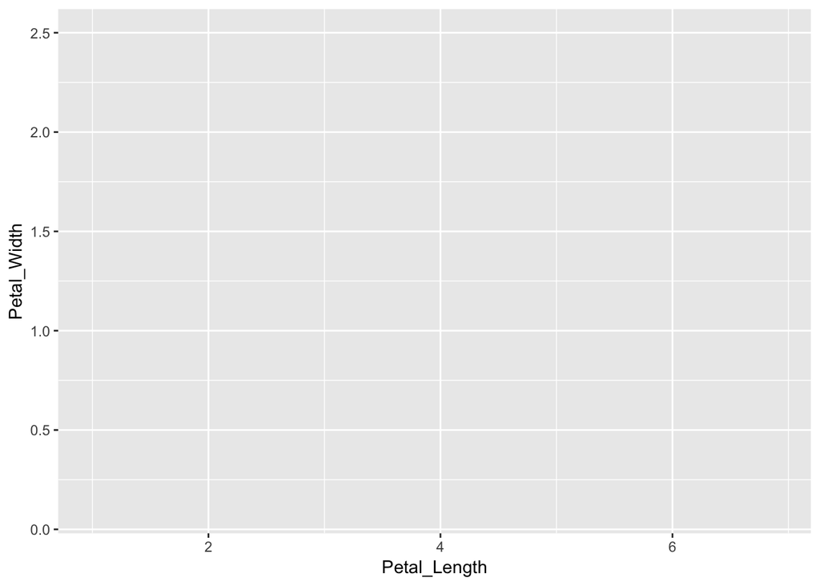

```r
# 基本起手式，產生畫布
library(ggplot2)
g <- ggplot(data=iris, # indicate which data you want to use
            aes(x=Petal_Length, y=Petal_Width)) # aes indicate x and y axis
print(g)
```

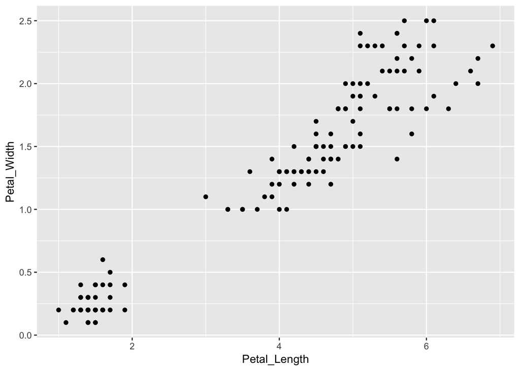

```r
g + geom_point() # 明確指明你要做哪一種繪圖方式，這邊選取的事散步圖或點圖
```

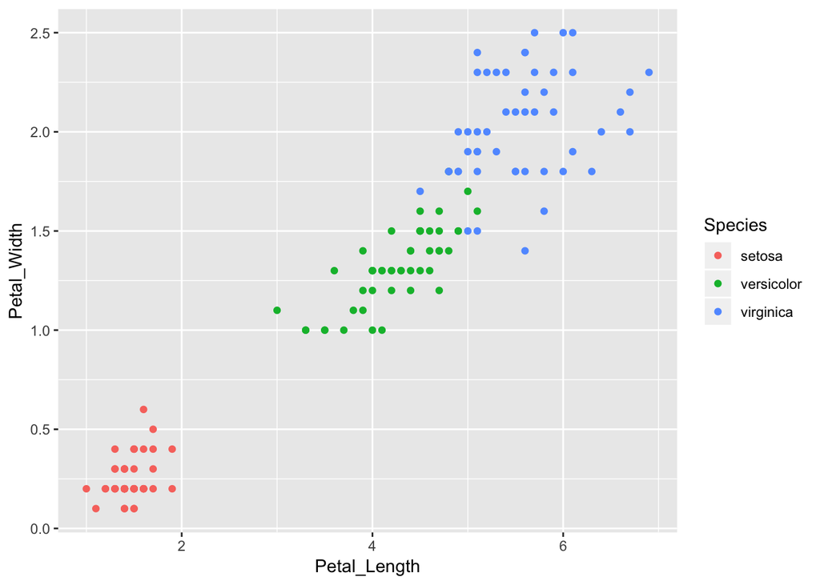

```r
g + geom_point(aes(color=Species)) # 由於我們有三種species，我們可以透過標記顏色觀察其分佈
```

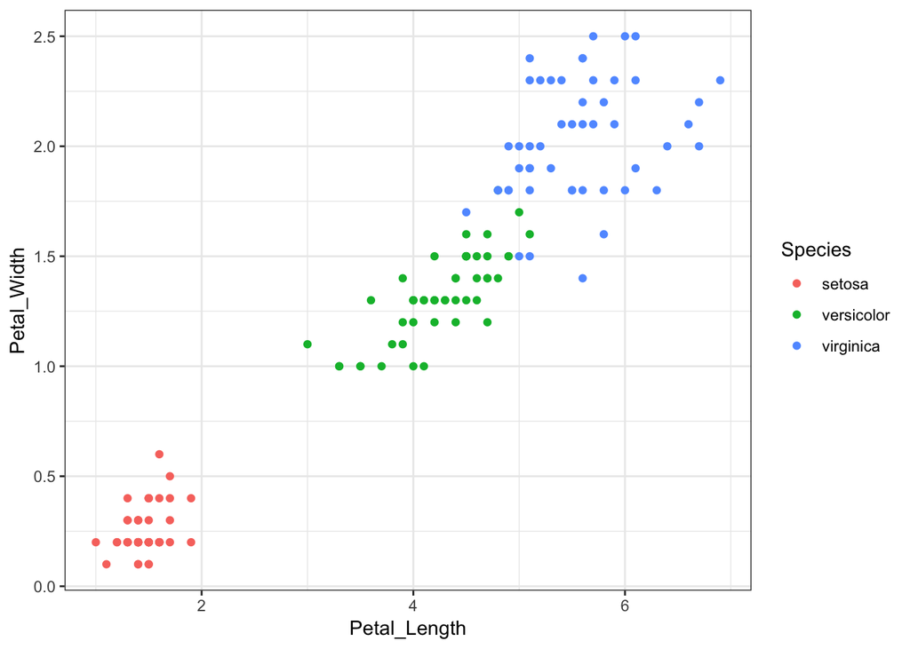

```r
# 是不是覺得背景很煩呢？，這邊我們提供幾個別人設計好的模板
library(ggthemes) # 提供數個模板，模板的樣式都是 theme_????
g + geom_point(aes(color=Species)) + theme_bw()
```

**補充資料**：[ggthemes](https://www.rdocumentation.org/packages/ggthemes/versions/3.5.0)

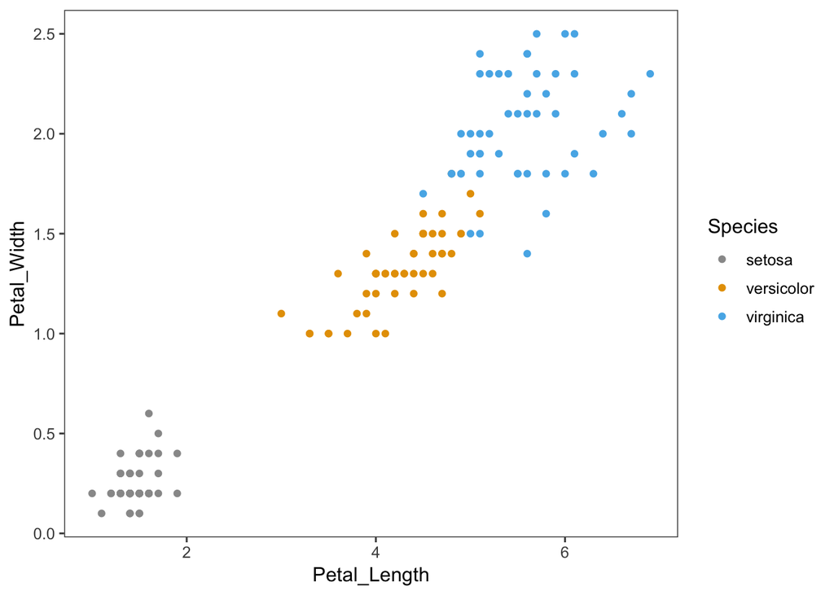

```r
# fill color
g + geom_point(aes(color=Species)) + theme_few() +
    scale_color_manual(values=c("#999999", "#E69F00", "#56B4E9"))
```

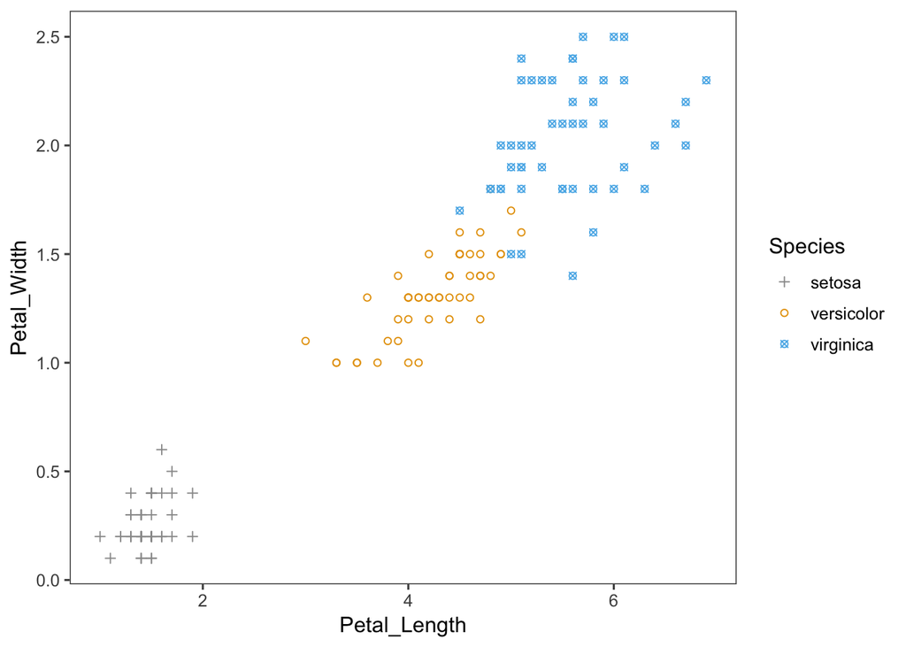

```r
# chage shape
g + geom_point(aes(color=Species, shape=Species)) + theme_few() +
    scale_color_manual(values=c("#999999", "#E69F00", "#56B4E9")) +
    scale_shape_manual(values=c(3,1,13))
```

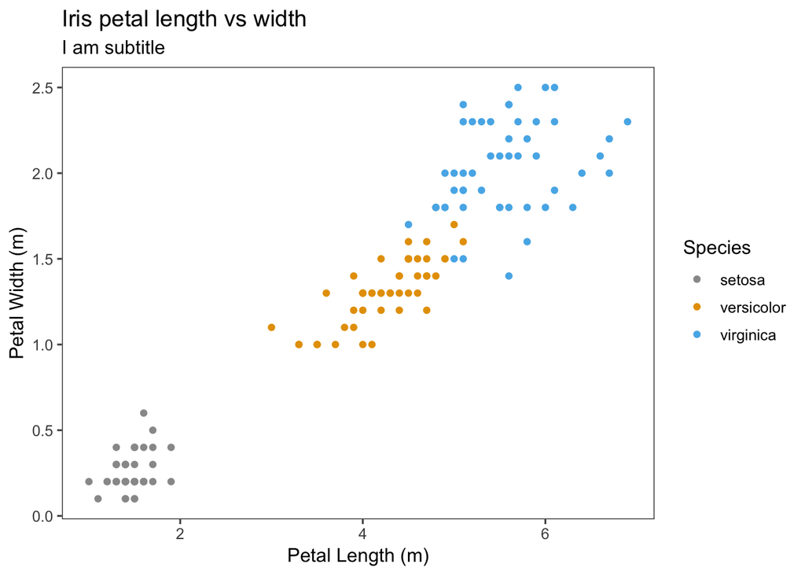

```r
# modify plot and axis title
g + geom_point(aes(color=Species)) + theme_few() +
    scale_color_manual(values=c("#999999", "#E69F00", "#56B4E9")) +
    labs(x="Petal Length (m)", y="Petal Width (m)",
         title="Iris petal length vs width", subtitle = "I am subtitle")
```

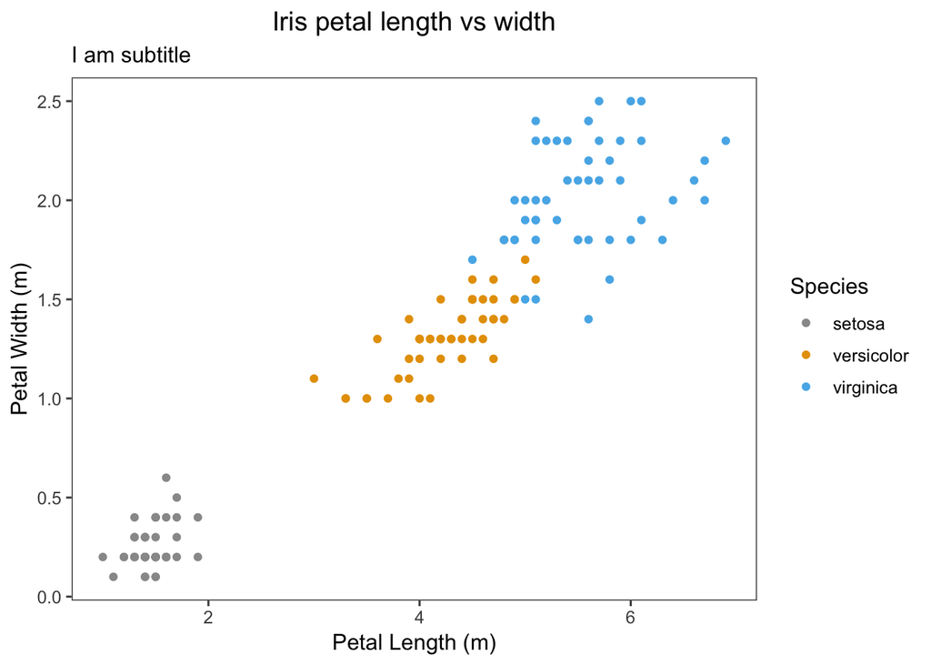

```r
# move plot title to middle of plot
g + geom_point(aes(color=Species)) + theme_few() +
    scale_color_manual(values=c("#999999", "#E69F00", "#56B4E9")) +
    labs(x="Petal Length (m)", y="Petal Width (m)",
         title="Iris petal length vs width", subtitle = "I am subtitle") +
    theme(plot.title = element_text(hjust = .5)) ####
```

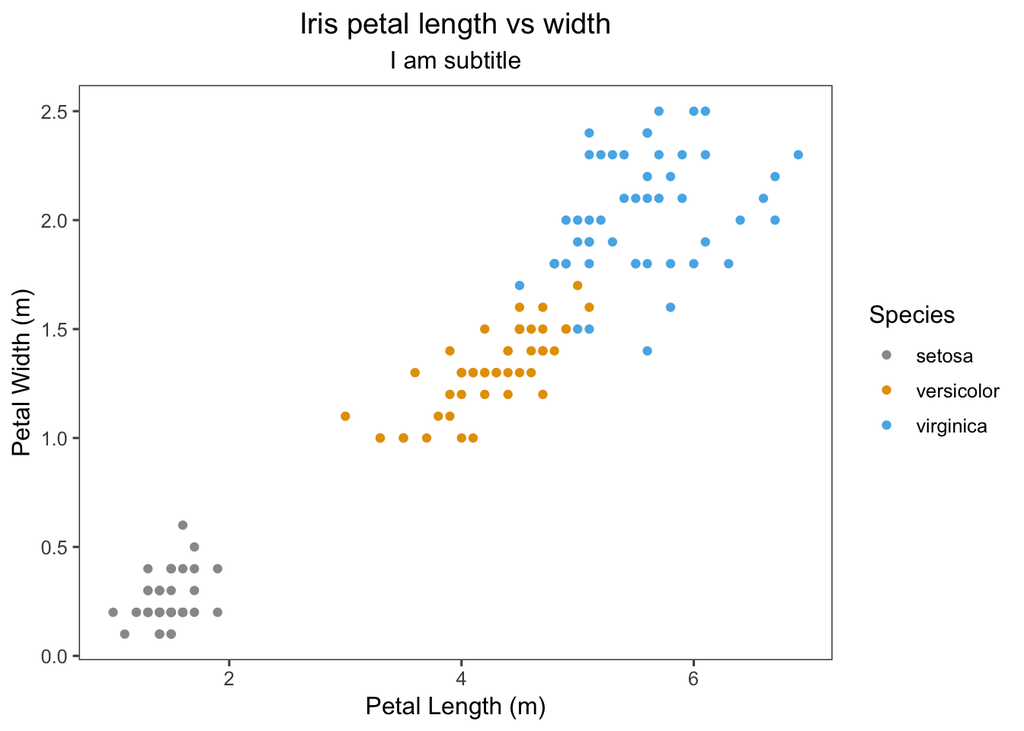

```r
# move plot title to middle of plot
g + geom_point(aes(color=Species)) + theme_few() +
    scale_color_manual(values=c("#999999", "#E69F00", "#56B4E9")) +
    labs(x="Petal Length (m)", y="Petal Width (m)",
         title="Iris petal length vs width", subtitle = "I am subtitle") +
    theme(plot.title = element_text(hjust = .5),
          plot.subtitle = element_text(hjust = .5)) ####
```

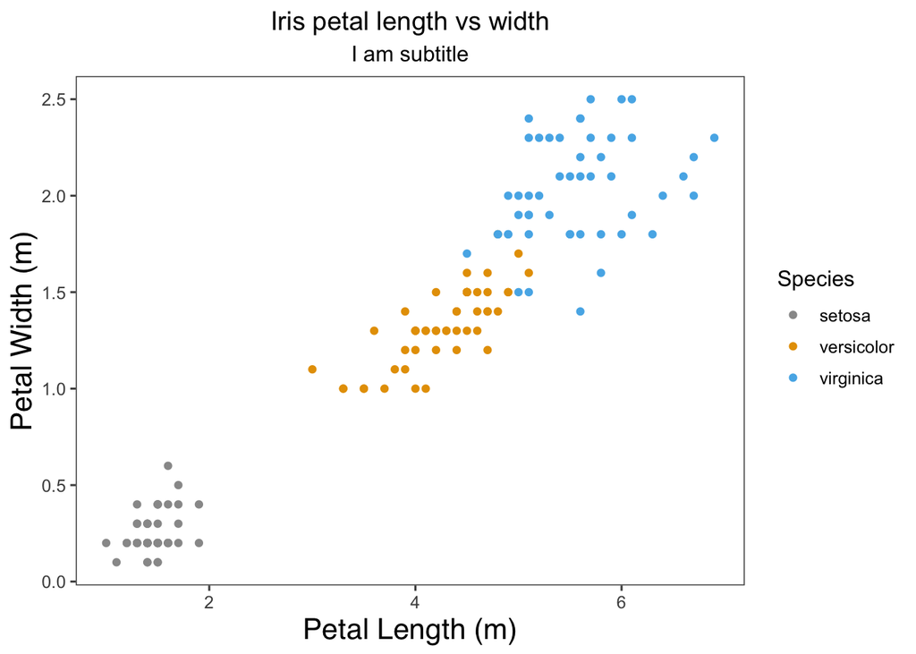

```r
# modify axis title
g + geom_point(aes(color=Species)) + theme_few() +
    scale_color_manual(values=c("#999999", "#E69F00", "#56B4E9")) +
    labs(x="Petal Length (m)", y="Petal Width (m)",
         title="Iris petal length vs width", subtitle = "I am subtitle") +
    theme(plot.title = element_text(hjust = .5),
          plot.subtitle = element_text(hjust = .5),
          axis.title = element_text(family="Helvetica", size = 16)) ####
```

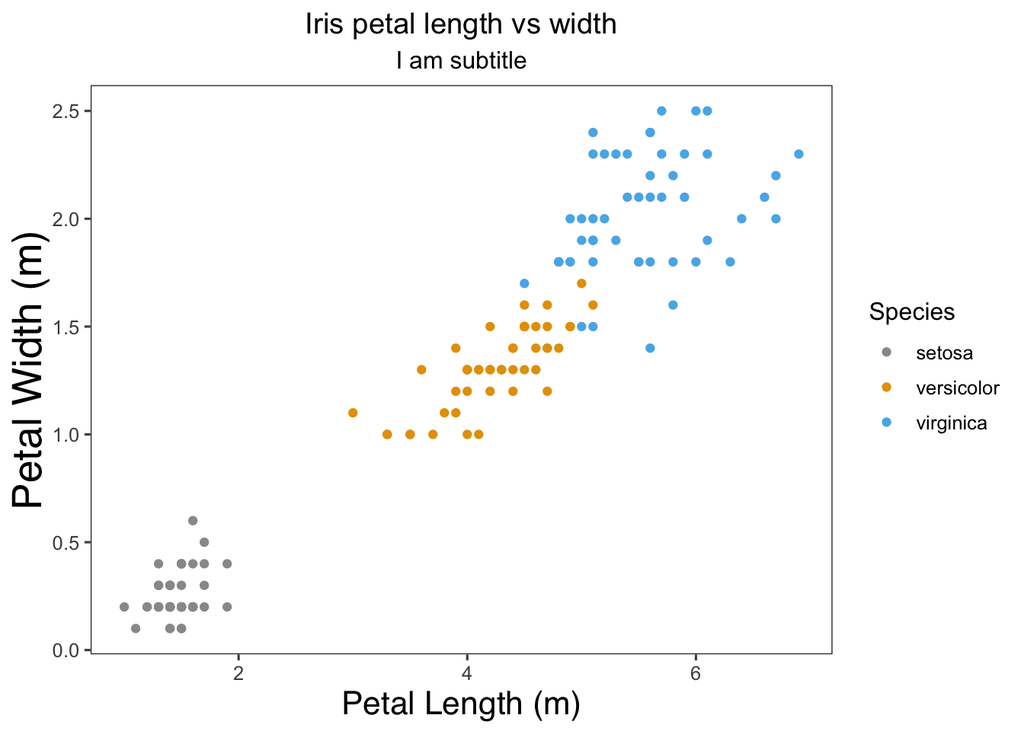

```r
# modify x and y axis respectively
g + geom_point(aes(color=Species)) + theme_few() +
    scale_color_manual(values=c("#999999", "#E69F00", "#56B4E9")) +
    labs(x="Petal Length (m)", y="Petal Width (m)",
         title="Iris petal length vs width", subtitle = "I am subtitle") +
    theme(plot.title = element_text(hjust = .5),
          plot.subtitle = element_text(hjust = .5),
          axis.title = element_text(family="Helvetica"), ####
          axis.title.x = element_text(size = 16), ####
          axis.title.y = element_text(size = 20)) ####
```

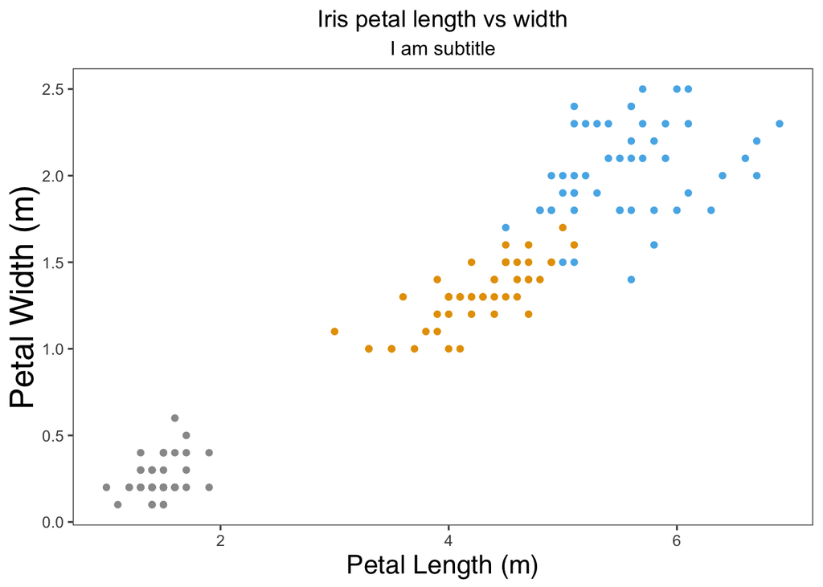

```r
# hide legend
final <- g + geom_point(aes(color=Species)) + theme_few() +
        scale_color_manual(values=c("#999999", "#E69F00", "#56B4E9")) +
        labs(x="Petal Length (m)", y="Petal Width (m)",
            title="Iris petal length vs width", subtitle = "I am subtitle") +
            theme(plot.title = element_text(hjust = .5),
            plot.subtitle = element_text(hjust = .5),
            axis.title = element_text(family="Helvetica"),
            axis.title.x = element_text(size = 16),
            axis.title.y = element_text(size = 20),
            legend.position = "none") # also can use c(x_position, y_position) to change position
print(final)
```

#### Box plot

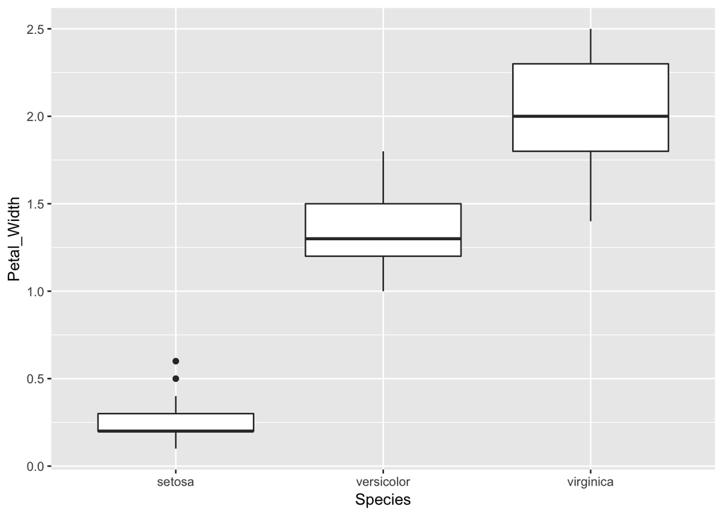

```r
# set x and y axis data
b <- ggplot(data=iris, aes(x=Species, y=Petal_Width))

# boxplot
b + geom_boxplot()
```

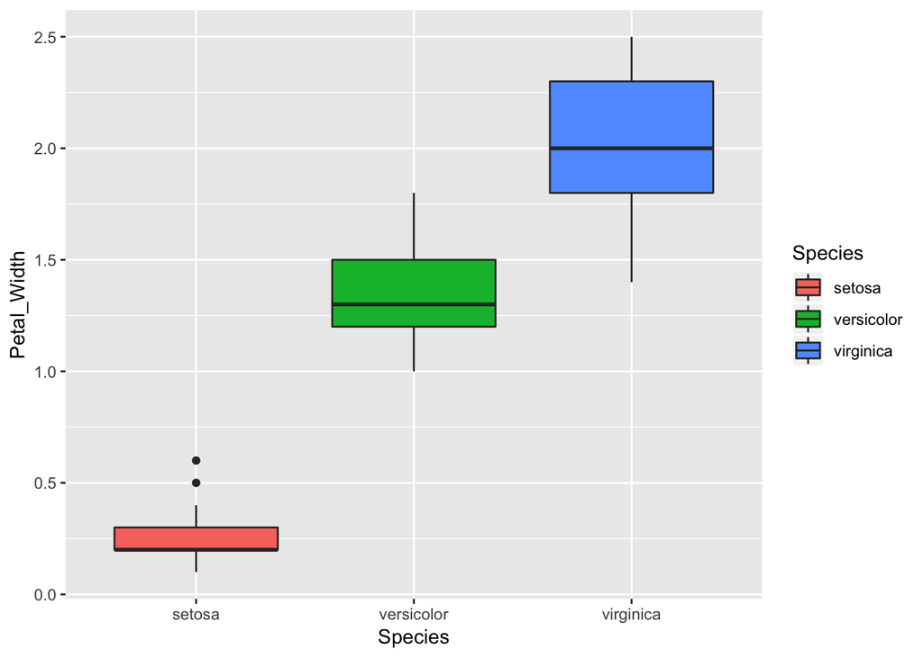

```r
# fill colour into boxplot
b + geom_boxplot(aes(fill=Species))
```

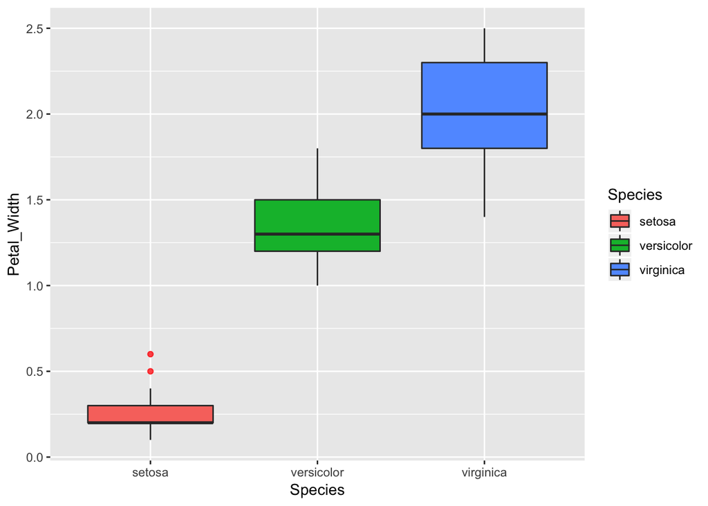

```r
# change outlier colour
b + geom_boxplot(aes(fill=Species),
                 outlier.color = "red",
                 outlier.alpha = .75)
```

#### Line chart

```r
line_segment <- pretty(c(1:20), 100)
y <- sin(line_segment)

sin_data <- data.frame(x=line_segment, y=y)
head(sin_data)
```

```
##     x         y
## 1 1.0 0.8414710
## 2 1.2 0.9320391
## 3 1.4 0.9854497
## 4 1.6 0.9995736
## 5 1.8 0.9738476
## 6 2.0 0.9092974
```

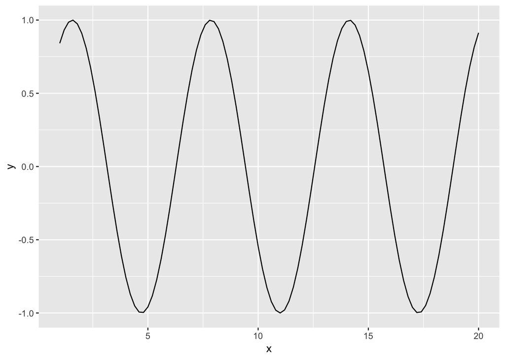

```r
ggplot(sin_data, aes(x=x, y=y)) + geom_line()
```

#### Save plot

圖表的可以儲存成`pdf()`, `jpeg()`, `tiff()`…，這邊為大家介紹兩個最常見的格式tiff and pdf。

```r
output_pdf_path <- "./iris.pdf"
# save as pdf
pdf(file = output_pdf_path,
    width = 5, height = 5)
print(final)
dev.off()
```

```r
output_tiff_path <- "./iris.tiff"
# save as tiff
tiff(file = output_tiff_path,
     width = 5, height = 5, units = "in", res = 300)
print(final)
dev.off()
```

#### Remind

由於這次內容也很多，希望同學可以花一點時間理解，在後續課程我會使用今天上課的內容，程式要常用才會記得住，有時候可以試著不使用excel，使用R來分析看看，加深自己的印象。如果有問題的話可以寄E-mail。 E-mail : steve24563@gmail.com